# NosAnalizamos

Julián Alcázar

2026-05-24

## 1. Introducción y Carga Automática de Datos

El objetivo de este script es realizar el procesamiento, la depuración y el análisis estadístico descriptivo del conjunto de datos del curso. El diseño permite conmutar la fuente de datos modificando únicamente la constante del fichero de entrada.

Cargamos el fichero de datos omitiendo las cabeceras descriptivas iniciales. La lectura se realiza de forma automática a partir de la fila 25, donde se detecta la estructura tabular auténtica de los datos.

```r
FICHERO_DATOS <- "data/NosAutoanalizamos2022 - Hoja1.tsv"

FICHERO_DATOS <- "data/NosAutoanalizamos2026 - NosAutoanalizamos (1).tsv"

lineas <- readLines(FICHERO_DATOS, warn = FALSE)
fila_cabecera <- grep("FechaNac|FechaNac\\(DD-MM-YYY\\)", lineas)

if (length(fila_cabecera) == 0) {
  stop("No se ha encontrado la fila de cabecera en el archivo tsv.")
}

# Lectura del set de datos a partir de la fila identificada
datos_raw <- read_tsv(FICHERO_DATOS, skip = fila_cabecera - 1, show_col_types = FALSE)
# Filtrar filas vacías o registros inconsistentes que carecen de identificador de alumno (Id)
datos <- datos_raw %>%
  filter(!is.na(Id) & Id != "" & !is.na(`FechaNac(DD-MM-YYY)`))

# Eliminar el registro del tutor o de ejemplo ('martsobm')
datos <- datos %>%
  filter(Id != "martsobm")

message(paste("Registros de alumnos cargados automáticamente:", nrow(datos)))
```

```
## Registros de alumnos cargados automáticamente: 60
```

## 2. Limpieza de Calificaciones

La variable de calificaciones contiene anomalías y diferentes formatos. Homogeneizamos los datos transformando el separador decimal a punto, sustituyendo “NC” por un valor de 3, y convirtiendo cualquier otra inconsistencia textual o no presentada en NA.

```r
limpiar_calificacion <- function(columna) {
  # Convertir a carácter y limpiar espacios
  col_char <- str_trim(as.character(columna))

  # Reemplazar 'NC' por la nota compensable estándar (3)
  col_char[col_char == "NC"] <- "3"
  col_char[col_char %in% c("NP", "NA", "NC", "")] <- NA

  # Sustituir comas por puntos decimales
  col_char <- str_replace(col_char, ",", ".")

  # Forzar transformación a numérico (valores erróneos de texto se convertirán en NA)
  col_num <- suppressWarnings(as.numeric(col_char))
  return(col_num)
}

# Aplicar la función de limpieza a las variables de asignaturas
calificaciones_clean <- datos %>%
  select(Id, Sex, Pulse, Height, Wr.Hnd, ALG, ANM, FP, DCS, MD) %>%
  mutate(
    ALG = limpiar_calificacion(ALG),
    ANM = limpiar_calificacion(ANM),
    FP = limpiar_calificacion(FP),
    DCS = limpiar_calificacion(DCS),
    MD = limpiar_calificacion(MD)
  )

# Exportar las calificaciones depuradas al archivo requerido en el examen
save(calificaciones_clean, file = "Notas.Rdata")
```

## 3. Tabla de Estadísticos Descriptivos

Obtenemos un resumen de medidas descriptivas de tendencia central y dispersión para cada una de las asignaturas. Los resultados se formatean a dos decimales de precisión.

```r
estadisticos_asignaturas <- calificaciones_clean %>%
  select(ALG, ANM, FP, DCS, MD) %>%
  pivot_longer(cols = everything(),
               names_to = "Asignatura",
               values_to = "Nota") %>%
  group_by(Asignatura) %>%
  summarise(
    `Mínimo` = round(min(Nota, na.rm = TRUE), 2),
    `Percentil 25` = round(quantile(Nota, probs = 0.25, na.rm = TRUE), 2),
    `Mediana` = round(median(Nota, na.rm = TRUE), 2),
    `Media` = round(mean(Nota, na.rm = TRUE), 2),
    `Desv. Típica` = round(sd(Nota, na.rm = TRUE), 2),
    `Percentil 75` = round(quantile(Nota, probs = 0.75, na.rm = TRUE), 2),
    `Máximo` = round(max(Nota, na.rm = TRUE), 2)
  )

kable(estadisticos_asignaturas, caption = "Estadísticos de Calificaciones del Curso")
```

Estadísticos de Calificaciones del Curso

| Asignatura | Mínimo | Percentil 25 | Mediana | Media | Desv. Típica | Percentil 75 | Máximo |
| --- | --- | --- | --- | --- | --- | --- | --- |
| ALG | 0.28 | 3.00 | 6.55 | 5.45 | 2.36 | 7.47 | 8.8 |
| ANM | 0.08 | 5.01 | 6.60 | 6.12 | 2.07 | 7.55 | 10.0 |
| DCS | 3.00 | 4.00 | 7.10 | 6.11 | 2.18 | 8.00 | 9.0 |
| FP | 0.80 | 3.00 | 3.00 | 4.40 | 2.39 | 7.00 | 8.6 |
| MD | 2.60 | 5.58 | 6.45 | 6.12 | 1.68 | 7.43 | 8.3 |

## 4. Análisis de Relaciones Bivariantes y Correlación

# Matriz de Dispersión Cruzada (ggpairs)

Utilizamos la librería GGally para visualizar la distribución conjunta y los coeficientes de correlación entre las asignaturas del cuatrimestre.

Al haber usuarios que poseen datos no finitos se considera hacer dos estudios; uno con dichos datos y otro sin ellos.

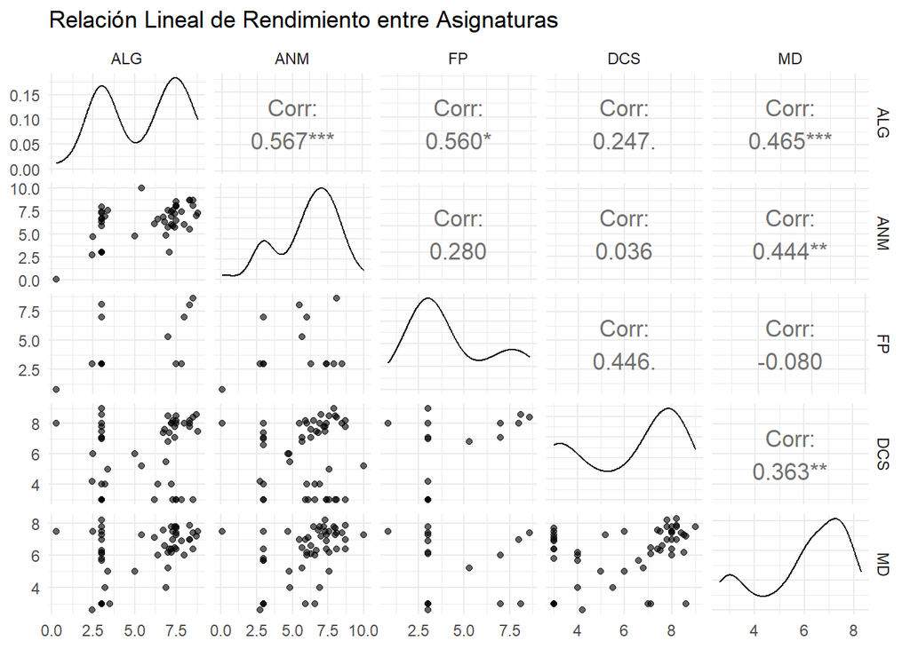

```r
ggpairs(
  calificaciones_clean,
  columns = c("ALG", "ANM", "FP", "DCS", "MD"),
  title = "Relación Lineal de Rendimiento entre Asignaturas",
  upper = list(continuous = wrap(
    "cor", method = "pearson", size = 4.5
  )),
  lower = list(continuous = wrap(
    "points", alpha = 0.6, size = 1.5
  ))
) +
  theme_minimal()
```

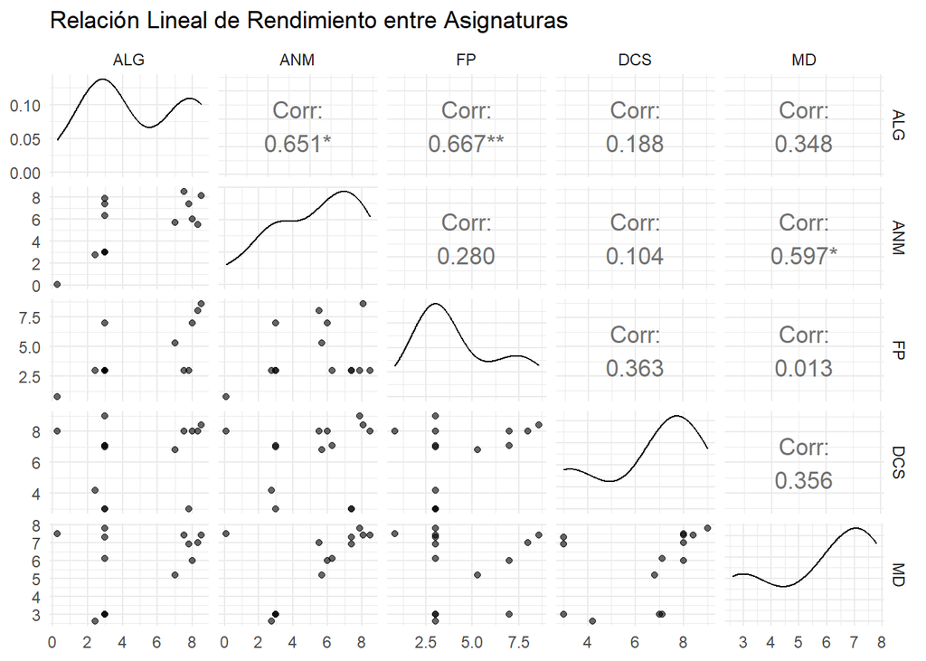

```r
calificaciones_clean %>%
  select(ALG, ANM, FP, DCS, MD) %>%
  na.omit() %>%  # Elimina temporalmente las filas con NA solo para la visualización
  ggpairs(
    title = "Relación Lineal de Rendimiento entre Asignaturas",
    upper = list(continuous = wrap(
      "cor", method = "pearson", size = 4.5
    )),
    lower = list(continuous = wrap(
      "points", alpha = 0.6, size = 1.5
    ))
  ) +
  theme_minimal()
```

# Matrices de Correlación (Pearson vs Spearman)

```r
notas_matriz <- calificaciones_clean %>%
  select(ALG, ANM, FP, DCS, MD) %>%
  na.omit()

# Correlación de Pearson
cor_pearson <- cor(notas_matriz, method = "pearson")
# Correlación de Spearman
cor_spearman <- cor(notas_matriz, method = "spearman")

cat("Matriz de Correlación de Pearson:\n")
```

```
## Matriz de Correlación de Pearson:
```

```r
print(round(cor_pearson, 2))
```

```
##      ALG  ANM   FP  DCS   MD
## ALG 1.00 0.65 0.67 0.19 0.35
## ANM 0.65 1.00 0.28 0.10 0.60
## FP  0.67 0.28 1.00 0.36 0.01
## DCS 0.19 0.10 0.36 1.00 0.36
## MD  0.35 0.60 0.01 0.36 1.00
```

```r
cat("\nMatriz de Correlación de Spearman:\n")
```

```
##
## Matriz de Correlación de Spearman:
```

```r
print(round(cor_spearman, 2))
```

```
##      ALG  ANM    FP  DCS    MD
## ALG 1.00 0.60  0.75 0.29  0.21
## ANM 0.60 1.00  0.22 0.31  0.58
## FP  0.75 0.22  1.00 0.31 -0.13
## DCS 0.29 0.31  0.31 1.00  0.61
## MD  0.21 0.58 -0.13 0.61  1.00
```

## 5. Visualizaciones de Rendimiento Académico

# Representación Boxplot General

Comparamos la distribución de notas obtenidas de forma global en las cinco áreas evaluadas.

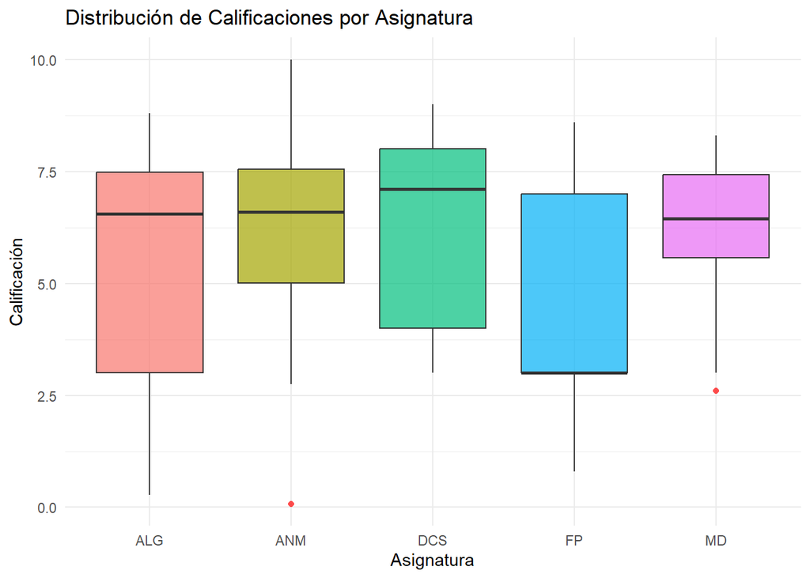

```r
calificaciones_clean %>%
  select(ALG, ANM, FP, DCS, MD) %>%
  pivot_longer(cols = everything(),
               names_to = "Asignatura",
               values_to = "Nota") %>%
  filter(!is.na(Nota)) %>%
  ggplot(aes(x = Asignatura, y = Nota, fill = Asignatura)) +
  geom_boxplot(
    alpha = 0.7,
    outlier.colour = "red",
    outlier.shape = 16
  ) +
  labs(title = "Distribución de Calificaciones por Asignatura", x = "Asignatura", y = "Calificación") +
  theme_minimal() +
  theme(legend.position = "none")
```

# Distribución de Calificaciones por Sexo

Añadimos la variable de clasificación por sexo para analizar diferencias de rendimiento académico grupal.

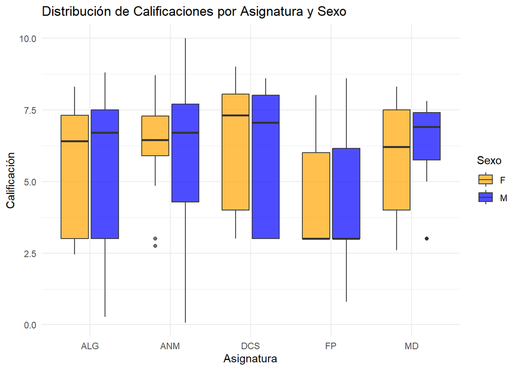

```r
# Normalización del etiquetado de Sexo (M y F)
calificaciones_sexo <- calificaciones_clean %>%
  mutate(Sex = case_when(
    Sex %in% c("M", "Masculino") ~ "M",
    Sex %in% c("F", "Femenino") ~ "F",
    TRUE ~ NA_character_
  )) %>%
  filter(!is.na(Sex))

calificaciones_sexo %>%
  select(Sex, ALG, ANM, FP, DCS, MD) %>%
  pivot_longer(cols = -Sex,
               names_to = "Asignatura",
               values_to = "Nota") %>%
  filter(!is.na(Nota)) %>%
  ggplot(aes(x = Asignatura, y = Nota, fill = Sex)) +
  geom_boxplot(alpha = 0.7) +
  labs(title = "Distribución de Calificaciones por Asignatura y Sexo",
       x = "Asignatura",
       y = "Calificación",
       fill = "Sexo") +
  scale_fill_manual(values = c("F" = "orange", "M" = "blue")) +
  theme_minimal()
```

# Evolución de Alumnos con Calificaciones Completas

Filtramos para conservar únicamente a los estudiantes que tienen registro de notas en la totalidad de las asignaturas. Representamos su evolución académica individualizada.

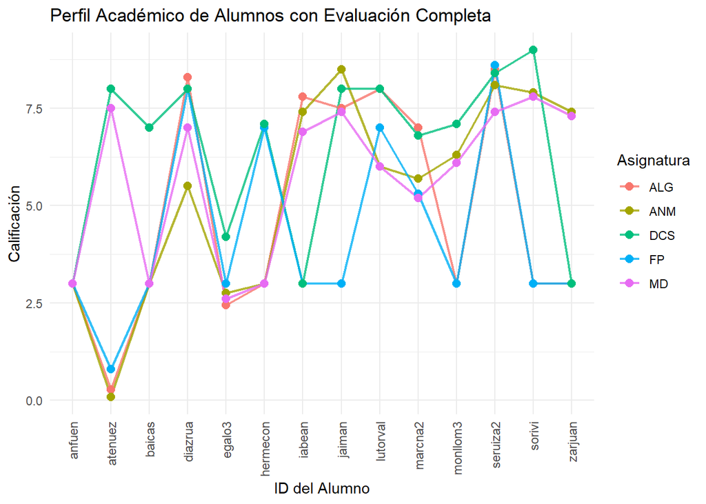

```r
alumnos_completos <- calificaciones_clean %>%
  filter(!is.na(ALG) &
           !is.na(ANM) & !is.na(FP) & !is.na(DCS) & !is.na(MD))

alumnos_completos_long <- alumnos_completos %>%
  select(Id, ALG, ANM, FP, DCS, MD) %>%
  pivot_longer(cols = -Id,
               names_to = "Asignatura",
               values_to = "Nota")

ggplot(alumnos_completos_long,
       aes(
         x = Id,
         y = Nota,
         group = Asignatura,
         color = Asignatura
       )) +
  geom_line(linewidth = 0.8, alpha = 0.8) +
  geom_point(size = 2.5) +
  labs(title = "Perfil Académico de Alumnos con Evaluación Completa", x = "ID del Alumno", y = "Calificación") +
  theme_minimal() +
  theme(axis.text.x = element_text(
    angle = 90,
    vjust = 0.5,
    hjust = 1,
    size = 9
  ))
```

# Respuestas preguntas 2026 (n=60 alumnos)

## 1. ¿Qué edad tiene el alumno más joven a 01/02/2026?

- gipicar, nacido el 19-12-2007 → 18,12 años

## 2. ¿Cuántos alumnos simultanean trabajo y estudios?

- 14 alumnos (Hwork > 0)

## 3. ¿Hay más hombres o mujeres fumadoras?

- Fumadores: 7 hombres, 0 mujeres. Hay más hombres fumadores (de hecho solo fuman hombres en este grupo)

## 4. Media y varianza de Wr.Hnd según sexo:

Sexo: Mujer: Media: 18.04 Varianza: 3.72 Hombre: Media: 19.99 Varianza: 1.73

## 5. ¿Existe relación entre sexo y NW.Hnd?

Sexo: Mujer: Derecha: 22 Izquierda: 2 Hombre: Derecha: 29 Izquierda: 7

## 6. ¿Existe relación lineal entre Height y Wr.Hnd?ç

- Correlación de Pearson = 0,43; correlación positiva moderada. Existe cierta relación lineal (personas más altas tienden a tener manos más grandes), pero no es muy fuerte.

## 7. ¿Hampel detecta outliers en Height?

- Mediana = 173,5 cm, MADM = 10,38; Límites: [142,4 ; 204,6]
- No se detecta ningún outlier en la variable altura.

## 8. Valor para imputación generalizada de FP (media):

- Media FP (2026) = 4,40 (sobre 17 alumnos con nota válida)

## 9. Imputación de FP por PulseCat (casos similares):

- A los alumnos sin nota de FP: si tienen PulseH se imputa 5,10, si tienen PulseL se imputa 4,14

## 10. ¿Qué decimos ante “el ritmo cardíaco tiene relación lineal con ALG”?

- Correlación Pearson(Pulse, ALG) = 0,14; correlación muy débil, prácticamente nula.

Los datos muestran que no existe relación lineal apreciable entre el ritmo cardíaco y las calificaciones en ALG. Además, correlación no implica causalidad — aunque existiera, necesitaríamos un diseño experimental controlado para establecer una relación causal.